# Documenting `sales_summary.R`

BDA400 Assignment 1 – Markdown Buddy

Nadeeka (Student ID: 664430944)

November 13, 2026

> **AI Assistance Declaration:** I used Claude (Anthropic, Opus 5.5) for Markdown layout and section-organisation suggestions for this R Markdown file. Prompts used: see `Appendix_AI_Prompts.md`. I verified outputs by knitting the file in R 4.6.1, checking every header and code chunk rendered, and comparing the printed totals with `output/region_summary.csv`. All final calculations are done by myself in R. I am responsible for the accuracy and originality of this work.

# Purpose

`scripts/sales_summary.R` creates a **synthetic** retail sales dataset (no real or personal data), summarises revenue by **region** and **product category**, and saves a summary table and a bar chart. It shows a simple, reproducible *generate → summarise → visualise* workflow.

| Input | Type | Description |
| --- | --- | --- |
| `set.seed()` | integer | Seed `400` makes the random data reproducible |
| `n_orders` | integer | Number of synthetic orders to create (`500`) |
| Packages | R library | `dplyr` (data wrangling), `ggplot2` (plotting) |

No external file is read – the script builds its own data.

## Outputs

| Output | Format | Description |
| --- | --- | --- |
| `data/synthetic_sales.csv` | CSV | 500 order-level rows |
| `output/region_summary.csv` | CSV | Orders, units, revenue and average by region |
| `output/revenue_by_region.png` | PNG | Grouped bar chart of revenue |

# Walkthrough

## Step 1 – Load packages and settings

```r
library(dplyr)
library(ggplot2)

set.seed(400)
n_orders <- 500
```

## Step 2 – Create the synthetic data

Each row is one order. `revenue` is calculated as `units × unit_price`.

```r
sales <- data.frame(
  order_id   = sprintf("ORD-%04d", 1:n_orders),
  order_date = sample(seq(as.Date("2026-01-01"), as.Date("2026-06-30"), by = "day"),
                      n_orders, replace = TRUE),
  region     = sample(c("East", "West", "North", "South"), n_orders, replace = TRUE),
  category   = sample(c("Furniture", "Office Supplies", "Technology"), n_orders,
                      replace = TRUE, prob = c(0.3, 0.45, 0.25)),
  units      = sample(1:10, n_orders, replace = TRUE),
  unit_price = round(runif(n_orders, min = 5, max = 250), 2)
)
sales$revenue <- round(sales$units * sales$unit_price, 2)

head(sales)
```

```
##   order_id order_date region        category units unit_price revenue
## 1 ORD-0001 2026-04-11  North       Furniture     4     211.90  847.60
## 2 ORD-0002 2026-04-28  South Office Supplies     5      34.93  174.65
## 3 ORD-0003 2026-01-23   East       Furniture     9     233.63 2102.67
## 4 ORD-0004 2026-03-28  South      Technology     4     132.45  529.80
## 5 ORD-0005 2026-03-27   East Office Supplies     8      10.97   87.76
## 6 ORD-0006 2026-06-05   West       Furniture    10      97.85  978.50
```

## Step 3 – Summarise by region

```r
region_summary <- sales %>%
  group_by(region) %>%
  summarise(
    orders        = n(),
    total_units   = sum(units),
    total_revenue = sum(revenue),
    avg_order     = round(mean(revenue), 2),
    .groups = "drop"
  ) %>%
  arrange(desc(total_revenue))

knitr::kable(region_summary, caption = "Revenue summary by region")
```

Revenue summary by region

| region | orders | total_units | total_revenue | avg_order |
| --- | --- | --- | --- | --- |
| North | 129 | 742 | 94812.80 | 734.98 |
| East | 127 | 703 | 92695.63 | 729.89 |
| South | 127 | 687 | 87001.75 | 685.05 |
| West | 117 | 632 | 82951.31 | 708.99 |

## Step 4 – Visualise revenue by region and category

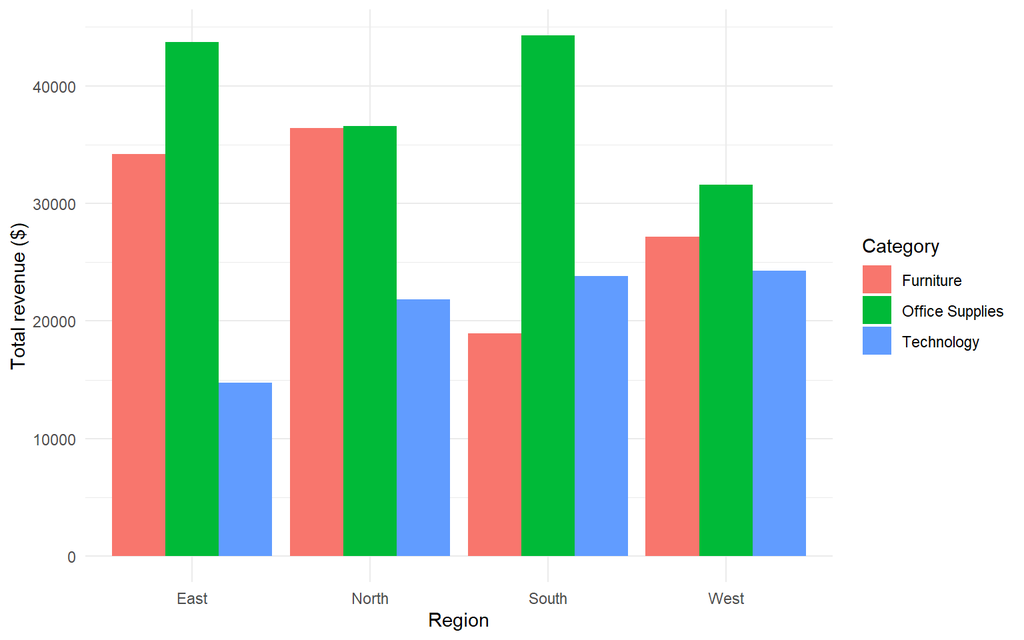

Revenue by region and category (synthetic data)

```r
category_summary <- sales %>%
  group_by(region, category) %>%
  summarise(total_revenue = sum(revenue), .groups = "drop")

ggplot(category_summary, aes(x = region, y = total_revenue, fill = category)) +
  geom_col(position = "dodge") +
  labs(x = "Region", y = "Total revenue ($)", fill = "Category") +
  theme_minimal()
```

# Verification

I cross-checked the summary in two independent ways:

1. **Base R recalculation** – totals computed with `tapply()` instead of `dplyr`.
2. **Grand-total check** – the regional totals must add up to the overall revenue.

```r
base_totals <- tapply(sales$revenue, sales$region, sum)

# 1. Same totals per region (tapply returns an array, so convert to numeric)
isTRUE(all.equal(as.numeric(base_totals[region_summary$region]),
                 region_summary$total_revenue))
```

```
## [1] TRUE
```

```r
# 2. Regional totals add up to the overall revenue
isTRUE(all.equal(sum(region_summary$total_revenue), sum(sales$revenue)))
```

```
## [1] TRUE
```

Both checks return `TRUE`.

# How to Run

```r
# From the project root folder:
source("scripts/sales_summary.R")

# Or knit this document:
rmarkdown::render("sales_summary.Rmd")
```